# Exploring the BRFSS data

## Setup

### Load packages

```r
library(ggplot2)
library(dplyr)
```

### Load data

Make sure your data and R Markdown files are in the same directory. When loaded your data file will be called `brfss2013`. Delete this note when before you submit your work.

```r
load("brfss2013.RData")
```

## Part 1: Data

The data collected by BRFSS used Random Digit Dialing (RDD) techniques to collect data from a random sample of the total population. Around 97.5% of the total US population had telephone coverage in 2012. This makes 2.5% of the population whom the result of the survey cannot be generalized. The survey language used was English and Spanish, leaving behind around 1% of the population. Moreover, the survey was only directed towards the adults but the 99% of the people refused to answer this question making this generalizable to the audience of every age. The data has fairly large number of males and female. Usually females are left behind in our society during such survey because of male dominance, but this survey has acted fairly in this regard. The survey questions consisted of only binary sex thus giving very vague information about others sexes i-e Trans. Although there have been some part of the US that has been left behind but the data collected can be generalized because it covers around 95% of the total population. In order to make the data perfect, a lot of financial sources would have been required. Inshort, data is a good bargain for the money spent on the surveys which can be generalized.

## Part 2: Research questions

**Research quesion 1:** Tobacco is a huge industry of the world. In order to increase their sales, they would like to know that which class of the people uses their products so that they can make their advertisements more user-centric. For this purpose, I will try to find a relationship between the income of the people and their usage of tobacco.

**Research quesion 2:** Sleep is an important part of human life. Now-a-days alot of males are not getting a good sleep. For this purpose I will investigate the type of sleep males are getting based on their incomes and to find any correlation between the two.

**Research quesion 3:** Body can play a crucial role in the personality of a person. In this question, I will try to find a relation between female’s fitness and the type of income she is getting.

## Part 3: Exploratory data analysis

**Research quesion 1:**

### Cleaning the NA from the variables I will be using to make visualizing easier

```r
new_set <- brfss2013 %>%
  select(usenow3, income2) %>%
  filter(!is.na(usenow3)) %>%
  filter(!is.na(income2))
```

### Plotting the income of the people

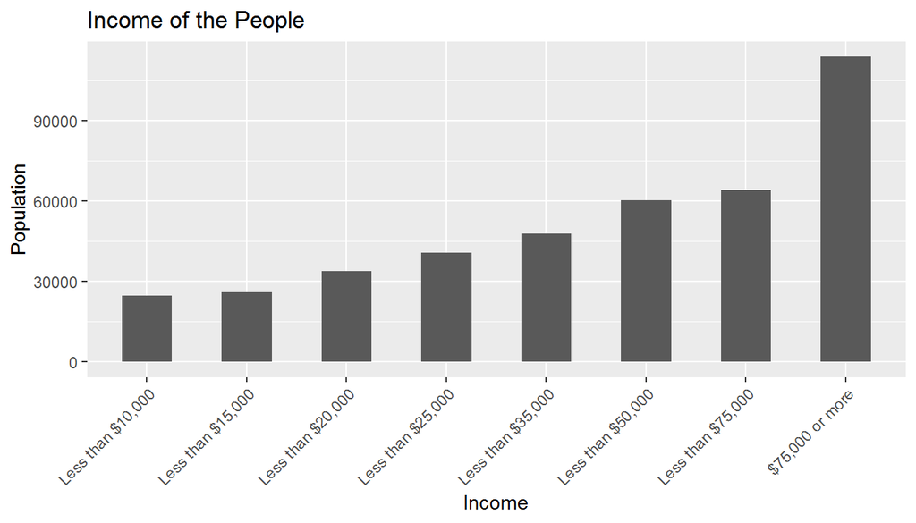

```r
ggplot(data = new_set, aes(x = income2))+
  ggtitle("Income of the People")+
  xlab("Income")+
  ylab("Population")+
  stat_count(width = 0.5)+
  theme(axis.text.x=element_text(angle = 45, hjust=1))
```

### Statistics of the income of the people

```r
new_set %>%
  group_by(Income = income2) %>%
  summarise(Percentage = 100 * n() /nrow(new_set))
```

```
## # A tibble: 8 x 2
##   Income            Percentage
##   <fct>                  <dbl>
## 1 Less than $10,000       6.01
## 2 Less than $15,000       6.35
## 3 Less than $20,000       8.24
## 4 Less than $25,000       9.90
## 5 Less than $35,000      11.6
## 6 Less than $50,000      14.7
## 7 Less than $75,000      15.6
## 8 $75,000 or more        27.7
```

This summary shows the statistics of the people based on their incomes. 27% percent of the people have their salaries greater than $75,000 which forms a major chunk of the population

### Visualizing the tobacco usage of people

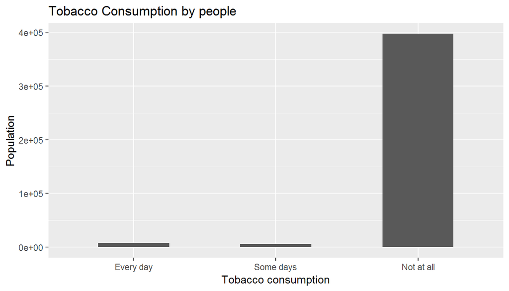

```r
ggplot(data = new_set, aes(x = usenow3))+
  ggtitle("Tobacco Consumption by people")+
  xlab("Tobacco consumption")+
  ylab("Population")+
  stat_count(width = 0.5)
```

This graph represents the tobacco consumption by the people. Here we can see that major portion of the people do not consume tobacco at all.

### Statistics of the tobacco usage

```r
new_set %>%
  group_by(tobacco_consumption = usenow3) %>%
  summarise(percentage = 100 * n() /nrow(new_set))
```

```
## # A tibble: 3 x 2
##   tobacco_consumption percentage
##   <fct>                    <dbl>
## 1 Every day                 1.90
## 2 Some days                 1.47
## 3 Not at all               96.6
```

This shows the statistics based on the tobacco consumption of the people.

### Visualization based on income and tobacco consumption

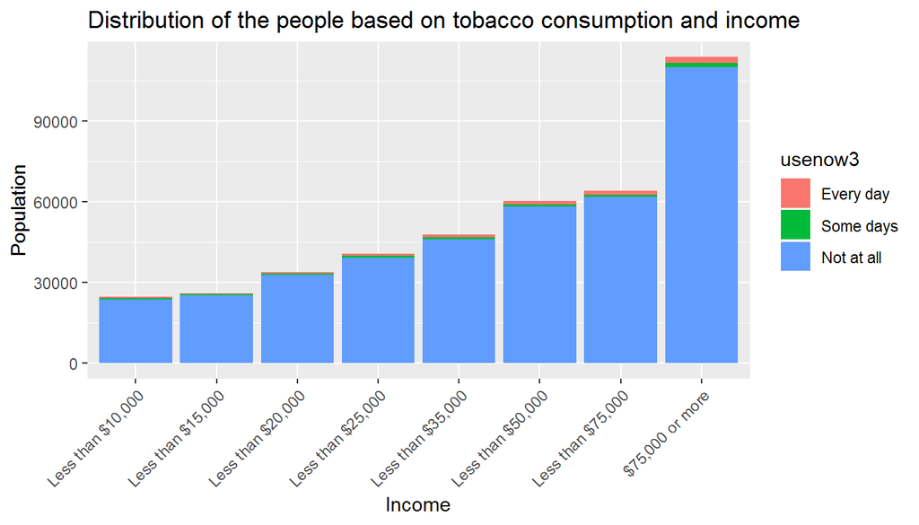

```r
ggplot(data = new_set ,aes(fill=usenow3, x = income2))+
  geom_bar() +
  ggtitle("Distribution of the people based on tobacco consumption and income")+
  xlab("Income")+
  ylab("Population")+
  theme(axis.text.x=element_text(angle = 45, hjust=1))
```

This graph represents the tobacco consumption based on the incomes of the people. We are interested in the people who use tobacco daily. For this, we need to filter out the people who use tobacco Every day

### Visualization based on daily tobacco consumption

```r
new_set %>%
  group_by(income2)%>%
  select(Income = income2,usenow3) %>%
  summarise(every_day = sum(usenow3 == "Every day"))
```

```
## # A tibble: 8 x 2
##   Income            every_day
##   <fct>                 <int>
## 1 Less than $10,000       431
## 2 Less than $15,000       445
## 3 Less than $20,000       493
## 4 Less than $25,000       751
## 5 Less than $35,000       907
## 6 Less than $50,000      1247
## 7 Less than $75,000      1421
## 8 $75,000 or more        2131
```

This table shows the people that use tobacco dailiy.

```r
set_everyday <- new_set %>%
  select(income2, usenow3)%>%
  filter(usenow3 == "Every day")
```

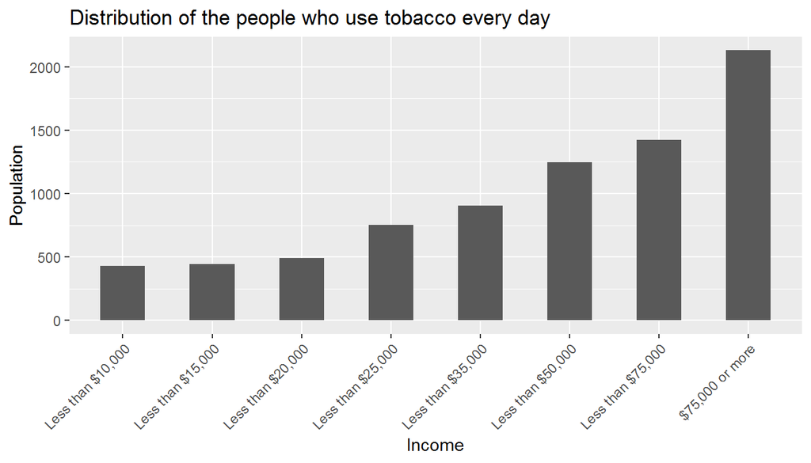

```r
ggplot(data = set_everyday ,aes(x = income2))+
  stat_count(width = 0.5) +
  ggtitle("Distribution of the people who use tobacco every day")+
  xlab("Income")+
  ylab("Population")+
  theme(axis.text.x=element_text(angle = 45, hjust=1))
```

This graph represent those people who consume tobacco daily. We can see that the graph is right skewed. Greater the income, greater the tobacco consumption. But this graph does not correctly interprets the relationship between tobacco consumption and income level. As we have seen above that people who earn more than $75000 were far greater then the other people, This result can thought to be biased as the number of people in that perticular class were greater.

```r
new_set %>%
  group_by(income2)%>%
  select(Income = income2,usenow3) %>%
  summarise(Every_day = sum(usenow3 == "Every day")/n())
```

```
## # A tibble: 8 x 2
##   Income            Every_day
##   <fct>                 <dbl>
## 1 Less than $10,000    0.0174
## 2 Less than $15,000    0.0170
## 3 Less than $20,000    0.0145
## 4 Less than $25,000    0.0185
## 5 Less than $35,000    0.0190
## 6 Less than $50,000    0.0207
## 7 Less than $75,000    0.0222
## 8 $75,000 or more      0.0187
```

We can remove the biase based on the percentage of the consumption in each group. According to this table, the max consumption is by the people with income $50000-$75000 .

**Research quesion 2:**

### Cleaning the variables to use

```r
q2_set <- brfss2013 %>%
  select(sex, income = income2, sleep = sleptim1) %>%
  filter(!is.na(income)) %>%
  filter(!is.na(sleep)) %>%
  filter(!is.na(sex))
```

### Visualizing the sex of the population

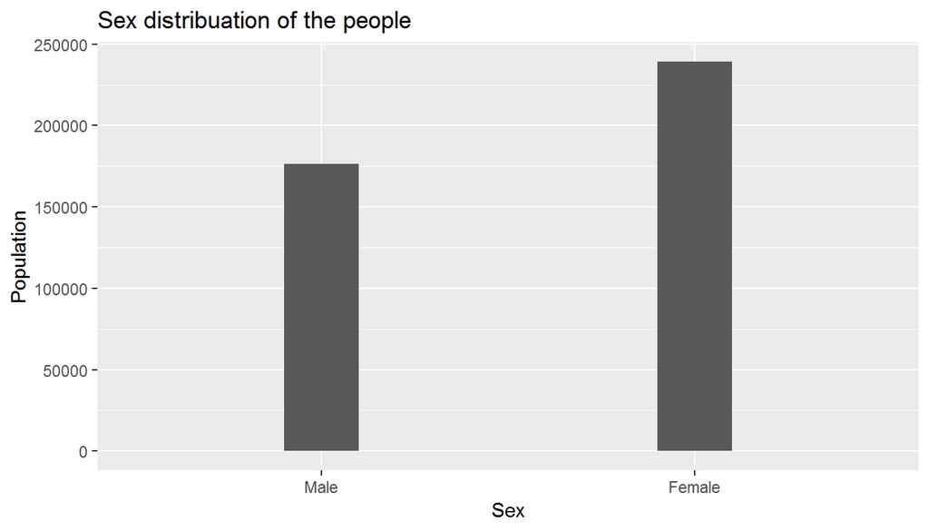

```r
ggplot(data = q2_set, aes(x = sex))+
  ggtitle("Sex distribuation of the people")+
  xlab("Sex")+
  ylab("Population")+
  stat_count(width = 0.2)
```

This plot shows the distribution of the male and female. We can see that most of the respondents were female

### Statistics of the sex

```r
q2_set %>%
  group_by(sex) %>%
  summarise(Percentage = 100 * n() /nrow(new_set))
```

```
## # A tibble: 2 x 2
##   sex    Percentage
##   <fct>       <dbl>
## 1 Male         42.9
## 2 Female       58.2
```

### Adding the sleep type

```r
q2_set <- q2_set %>%
  mutate(sleep_type = ifelse(sleep < 7, "Not Good Sleep","Good Sleep" ))
```

Sleep less than 7 hours daily is not enough for people. So I have made a new variable in the data sleep_type that represents whether the people are getting enough sleep

### Visualizing the sleep type of the people

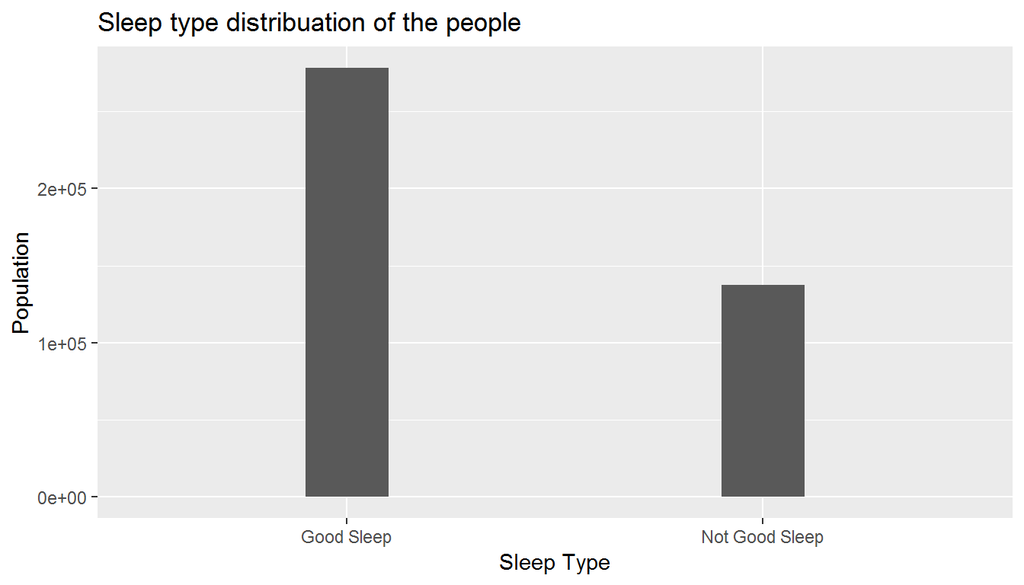

```r
ggplot(data = q2_set, aes(x = sleep_type))+
  ggtitle("Sleep type distribuation of the people")+
  xlab("Sleep Type")+
  ylab("Population")+
  stat_count(width = 0.2)
```

Here, we can see that majority of the people are getting good sleep.

### Statistics of the sleep

```r
q2_set %>%
  group_by(sleep_type) %>%
  summarise(Percentage = 100 * n() /nrow(new_set))
```

```
## # A tibble: 2 x 2
##   sleep_type     Percentage
##   <chr>               <dbl>
## 1 Good Sleep           67.7
## 2 Not Good Sleep       33.5
```

This table shows that approxiamtely 68% of the people are having a good sleep

### Visualizing sleep for men

As our question want to find the relationship between income and sleep in males, we need to filter out females from the data set

```r
q2 <- q2_set %>%
  filter(sex == "Male")
```

This will give us the data only for males

Now lets visualize the sleep type in males

[figure not shown]

```r
ggplot(data = q2_set, aes(x = sleep_type))+
  ggtitle("Sleep type distribution of the males")+
  xlab("Sleep Type")+
  ylab("Population")+
  stat_count(width = 0.2)
```

Here, we can see in the graph that a huge portion of the participants get a good sleep

```r
q2_set %>%
  group_by(sleep_type) %>%
  summarise(Percentage = 100 * n() /nrow(q2_set))
```

```
## # A tibble: 2 x 2
##   sleep_type     Percentage
##   <chr>               <dbl>
## 1 Good Sleep           66.9
## 2 Not Good Sleep       33.1
```

Here we can see that sleep type ratio is pretty much the same

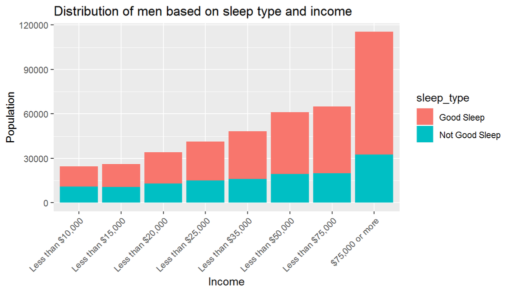

```r
ggplot(data = q2_set ,aes(fill=sleep_type, x = income))+
  geom_bar() +
  ggtitle("Distribution of men based on sleep type and income")+
  xlab("Income")+
  ylab("Population")+
  theme(axis.text.x=element_text(angle = 45, hjust=1))
```

```r
q2_set %>%
  group_by(income)%>%
  select(Income = income,sleep_type) %>%
  summarise(good_sleep = sum(sleep_type == "Good Sleep")/n(), not_good_sleep = sum(sleep_type == "Not Good Sleep")/n())
```

```
## # A tibble: 8 x 3
##   Income            good_sleep not_good_sleep
##   <fct>                  <dbl>          <dbl>
## 1 Less than $10,000      0.561          0.439
## 2 Less than $15,000      0.588          0.412
## 3 Less than $20,000      0.618          0.382
## 4 Less than $25,000      0.637          0.363
## 5 Less than $35,000      0.665          0.335
## 6 Less than $50,000      0.683          0.317
## 7 Less than $75,000      0.694          0.306
## 8 $75,000 or more        0.717          0.283
```

It is evident from the table that as the income of the people is increasing, the percentage of the people who are getting a good sleep are also increasing.

```r
q2_set %>%
  group_by(income) %>%
  select(Income = income,sleep_type) %>%
   summarise(good_sleep = sum(sleep_type == "Good Sleep"), not_good_sleep = sum(sleep_type == "Not Good Sleep"))
```

```
## # A tibble: 8 x 3
##   Income            good_sleep not_good_sleep
##   <fct>                  <int>          <int>
## 1 Less than $10,000      13824          10825
## 2 Less than $15,000      15350          10762
## 3 Less than $20,000      21145          13066
## 4 Less than $25,000      26233          14952
## 5 Less than $35,000      32145          16182
## 6 Less than $50,000      41705          19363
## 7 Less than $75,000      45084          19832
## 8 $75,000 or more        82820          32635
```

**Research quesion 3:**

### Cleaning the variables to use

```r
q3_set <- brfss2013 %>%
  select(income = income2, height = htm4, weight = wtkg3, sex) %>%
  filter(!is.na(income)) %>%
  filter(!is.na(height)) %>%
  filter(!is.na(sex)) %>%
  filter(!is.na(weight))
```

### Calculating BMI of the people

```r
q3_set <- q3_set %>%
  mutate(bmi = weight/height^2 * 100) %>%
  mutate(fitness = ifelse(bmi >= 18.5 & bmi < 25, "Fit","Not Fit"))
```

Now, the variable bmi will have the bmi of all the participants and fitness will tell about the fitness of the people

### Visualizing fitness of the people

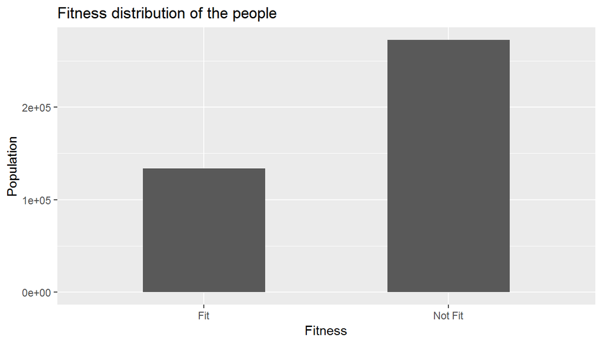

```r
ggplot(data = q3_set, aes(x = fitness))+
  ggtitle("Fitness distribution of the people")+
  xlab("Fitness")+
  ylab("Population")+
  stat_count(width = 0.5)
```

Here, we can see that fit people are nearly half as the non-fit ones.

### Statistics of the fitness of people

```r
q3_set %>%
  group_by(fitness) %>%
  summarise(Percentage = 100 * n() /nrow(q3_set))
```

```
## # A tibble: 2 x 2
##   fitness Percentage
##   <chr>        <dbl>
## 1 Fit           32.9
## 2 Not Fit       67.1
```

From the upper statistics, it is evident that fit people are nearly half as the non fit people

### Visualizing fitness of the females

```r
q3_set <- q3_set %>%
  filter (sex == "Female")
```

Removing the data of the males from our set

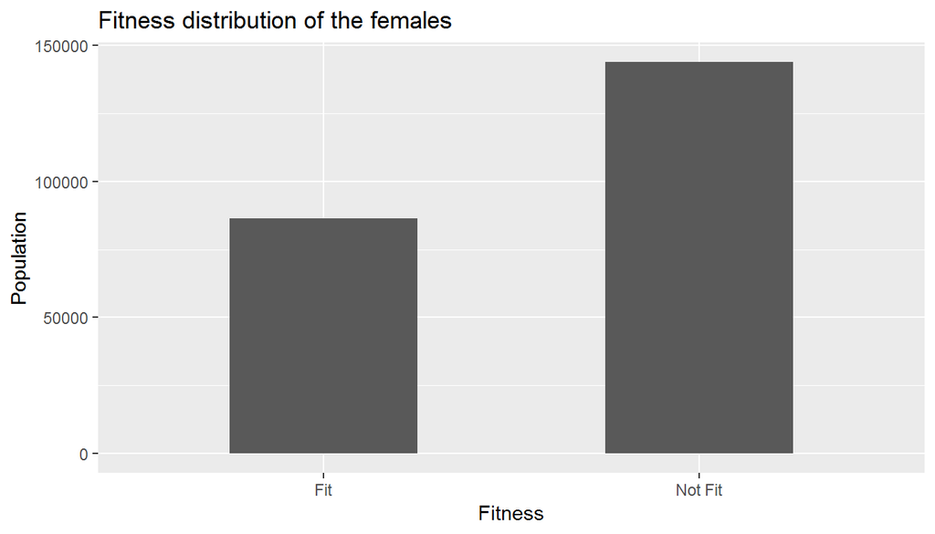

```r
ggplot(data = q3_set, aes(x = fitness))+
  ggtitle("Fitness distribution of the females")+
  xlab("Fitness")+
  ylab("Population")+
  stat_count(width = 0.5)
```

Here, we can see that the fitness has increased. This means that females are more fit as compared to the males

### Statistics of the fitness of women

```r
q3_set %>%
  group_by(fitness) %>%
  summarise(Percentage = 100 * n() /nrow(q3_set))
```

```
## # A tibble: 2 x 2
##   fitness Percentage
##   <chr>        <dbl>
## 1 Fit           37.6
## 2 Not Fit       62.4
```

Here, we can see that fit women are not half as compared to non-fit one. the perrcentage of fit women are 37% as compared to the total population that were 32%.

### Distribution of women based on income and their fitness

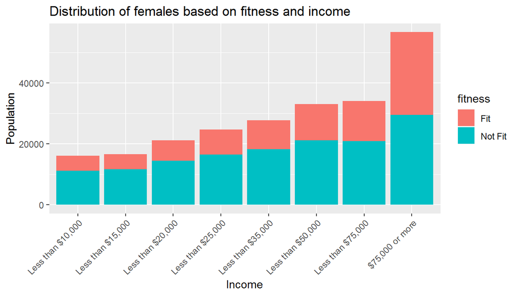

```r
ggplot(data = q3_set ,aes(fill=fitness, x = income))+
  geom_bar() +
  ggtitle("Distribution of females based on fitness and income")+
  xlab("Income")+
  ylab("Population")+
  theme(axis.text.x=element_text(angle = 45, hjust=1))
```

We can see from the above graph that as the the income is increasing, the fitness of the females are also increasing.

### Statistics of the females based on income and their fitness

```r
q3_set %>%
  group_by(income)%>%
  select(Income = income,fitness) %>%
  summarise(fit = sum(fitness == "Fit")/n(), not_fit = sum(fitness == "Not Fit")/n())
```

```
## # A tibble: 8 x 3
##   Income              fit not_fit
##   <fct>             <dbl>   <dbl>
## 1 Less than $10,000 0.302   0.698
## 2 Less than $15,000 0.298   0.702
## 3 Less than $20,000 0.315   0.685
## 4 Less than $25,000 0.331   0.669
## 5 Less than $35,000 0.343   0.657
## 6 Less than $50,000 0.358   0.642
## 7 Less than $75,000 0.387   0.613
## 8 $75,000 or more   0.480   0.520
```